# Arkhangelsky_Imbens_2022_Project

Omer Erhan Erbis 3466411

# Loading Libraries

```r
rm(list = ls())

# Loading required libraries
library(mvtnorm)
library(pryr)
library(kableExtra)
```

## Simulation Functions

The simulations are going to be performed with several functions, which are defined as follows. The simulation data is originated from Charles and Stephens (2013) paper which contains unspecified heterogeneity sources, as desired. There is a random component that is introduced at the creation of decomposed matrices. Together these processes make the data semi-random for the simulation purposes while carrying possibility of multiple heterogeneity sources.

data_preparation() performs SVD-decomposition and decomposed data generation, cor_matrix_compl() performs the correlation and covariance matrix calculations and est_function() function performs k-means algrithm and clustering that is in turn utilized in weight and treatment effect calculations for groups, eventually aggregating all the clusters with associated weights to calculate final treatment effect estimator.

```r
data_preparation <- function(data_mat,rank){

# this function extracts two-way fixed effects, and low-rank component of a given matrix

    n <- dim(data_mat)[1]
    T <- dim(data_mat)[2]

    svd_data_mat <- svd(data_mat)
    factor_unit <- as.matrix(svd_data_mat$u[,1:rank]*sqrt(n))
    factor_time <- as.matrix(svd_data_mat$v[,1:rank]*sqrt(T))

    magnitude <- svd_data_mat$d[1:rank]/sqrt(n*T)
    L_mat_orig <- factor_unit%*%diag(magnitude, nrow = rank, ncol = rank)%*%t(factor_time)

    error_mat <- data_mat-L_mat_orig
    F_mat <- outer(rowMeans(L_mat_orig),rep(1,T)) +
        outer(rep(1,n),colMeans(L_mat_orig)) - mean(L_mat_orig)
    L_mat <- L_mat_orig - F_mat

    return(list(L_mat,F_mat,error_mat))
}

cor_matrix_compl <- function(ar_coef,T_cur) {

# This function constructs the correlation matrix of size T_cur, from given AR(2) coefficients.



    result <- rep(0,T_cur)
    result[1] <- 1
    result[2] <- ar_coef[1]/(1-ar_coef[2])
    for (t in 3:T_cur){
        result[t] <-  ar_coef[1]*result[t-1]+ ar_coef[2]*result[t-2]
    }

    index_matrix <- outer(1:T_cur, 1:T_cur, function(x,y){ abs(y-x)+1})
    cor_matrix <- matrix(result[index_matrix],ncol = T_cur,nrow = T_cur)

    return(cor_matrix)
}


est_function <- function(W,Y,Z,K){

## This function takes assignment, data, aggregate shocks and number of clusters K

    n <- dim(W)[1]
    T <- dim(W)[2]

    S <- W%*%Z/T
    # set.seed(1234)
    clust_res <- kmeans(S,K, iter.max = 20)
    clust_ind <- clust_res$cluster
    results_full <- matrix(0,ncol = 2, nrow = K)

    for(k in 1:K){

        index_k <- clust_ind == k
        if (sum(index_k) > 1){
        Y_k <- Y[index_k,]
        W_k <- W[index_k,]
        n_k <- sum(index_k)
        weights_k_unnorm <- W_k - outer(rep(1,n_k),colMeans(W_k)) - outer(rowMeans(W_k),rep(1,T)) + mean(W_k)
        weights_k <- weights_k_unnorm/(norm(weights_k_unnorm,'f')^2)
        tau_k <- sum(Y_k*weights_k)
        results_full[k,] <- c(tau_k,n_k)
        }
        else {
        results_full[k,] <- c(NA,NA)
        }
    }

    agg_tau <- weighted.mean(results_full[,1],results_full[,2],na.rm = TRUE)


    return(agg_tau)
}
```

# Data

## Data Import

The processed Charles and Stephens (2013) data (by Arkhangelsky, Imbens (2022)) is imported.

```r
load('final_data.r')
```

## Reproducible Results by Setting Seed

```r
set.seed(1234)
```

## Data Assignment

```r
# Provided variables
Y <- full_data[[1]]
W <- full_data[[2]]
D_1 <- full_data[[3]]
D_2 <- full_data[[4]]
Z_1 <- full_data[[5]] - mean(full_data[[5]])
Z_2 <- full_data[[6]] - mean(full_data[[6]])
# Data dimensions
n <- dim(Y)[1]
T <- dim(Y)[2]
# Constant + Covariates
Z <- cbind(1,Z_1,Z_2)
## Number of clusters
K_1 <- floor(n/(1.25))
K_2 <- floor(n/(1.5))
K_3 <- floor(n/2)
K_4 <- floor(n/4)
K_5 <- floor(n/8)
K_6 <- floor(n/16)
K_7 <- floor(n/32)
K_8 <- 1
K_vec <- c(K_1, K_2, K_3, K_4, K_5, K_6, K_7, K_8)
```

# Parameters for Simulation

```r
rank_mat <- 4
# Treatment effect
tau <- 0
# Selection bias introduction
zeta_1 <- 0.0
zeta_2 <- 0.01
zeta_3 <- 0.03
zeta_4 <- 0.05
# Simulation quantity
B <- 1000
```

# Data Manipulation for Simulation

```r
# Value normalization
W_norm <- (W -mean(W))/(norm(W-mean(W),'f')/sqrt(n*T))
Y_norm <- (Y -mean(Y))/(norm(Y-mean(Y),'f')/sqrt(n*T))

# Decomposition
Y_decomp <- data_preparation(Y_norm,rank_mat)
W_decomp <- data_preparation(W_norm,rank_mat)

# Assignment of decomposed values
L_mat_y <-Y_decomp[[1]]
F_mat_y <- Y_decomp[[2]]
E_mat_y <- Y_decomp[[3]]

L_mat_w <-W_decomp[[1]]
F_mat_w <- W_decomp[[2]]
E_mat_w <- W_decomp[[3]]


# Correlation & Covariance matrix creation
cor_matrix_w <- cor_matrix_compl(c(0,0),T)
scale_var_w <- norm(t(E_mat_w)%*%E_mat_w/n,'f')/norm(cor_matrix_w,'f')
cov_mat_w <- cor_matrix_w*scale_var_w

cor_matrix_y <- cor_matrix_compl(c(0,0),T)
scale_var_y <- norm(t(E_mat_y)%*%E_mat_y/n,'f')/norm(cor_matrix_y,'f')
cov_mat_y <- cor_matrix_y*scale_var_y
```

# Component Sizes

```r
size_L_w <- round(norm(L_mat_w,'f')^2/(n*T),3)
size_F_w <- round(norm(F_mat_w,'f')^2/(n*T),3)
size_E_w <- round(norm(E_mat_w,'f')^2/(n*T),3)

size_L_y <- round(norm(L_mat_y,'f')^2/(n*T),3)
size_F_y <- round(norm(F_mat_y,'f')^2/(n*T),3)
size_E_y <- round(norm(E_mat_y,'f')^2/(n*T),3)

rho_er <- sum(diag(E_mat_w%*%t(E_mat_y)/(T*n)))/(sqrt(size_E_w*size_E_y))
rho_L <- sum(diag(L_mat_w%*%t(L_mat_y)/(T*n)))/(sqrt(size_L_w*size_L_y))
rho_F <- sum(diag(F_mat_w%*%t(F_mat_y)/(T*n)))/(sqrt(size_F_w*size_F_y))



sizes_orig <- round(rbind(c(size_L_w,size_F_w,size_E_w),
                c(size_L_y,size_F_y,size_E_y),
                c(rho_L, rho_F, rho_er)),2)

colnames(sizes_orig) <- c('L','F','E')
rownames(sizes_orig) <- c('W','Y','cor')
```

# Simulations

## Design 1 - No Selection Bias

```r
rho <- 1-zeta_1
upd_L_y <- rho*L_mat_y+sqrt(1-rho^2)*L_mat_w*sqrt(size_L_y/size_L_w)
size_upd_L_y <- round(norm(upd_L_y,'f')^2/(n*T),3)
norm_L_y <- upd_L_y*sqrt(size_upd_L_y/size_L_y)

sim_res_1 <- do.call(rbind,lapply(1:B, function(b) {

    index_b <- sample(1:n, n,replace = TRUE)
    noise_w <- rmvnorm(n,sigma = cov_mat_w)
    noise_y <- rmvnorm(n,sigma = cov_mat_y)

    W_b <- L_mat_w[index_b,] +F_mat_w[index_b,] + noise_w
    Y_b <- norm_L_y[index_b,] +F_mat_y[index_b,] +tau*W_b+ noise_y*sqrt(1-rho_er^2) +  noise_w*rho_er*sqrt(size_E_y/size_E_w)

    tau_calc <- pryr::partial(est_function, W=W_b,Y=Y_b,Z=Z)
    a_tau_coll <- sapply(K_vec, FUN=tau_calc)

    return(a_tau_coll)
}))
```

## Design 2 - Selection Bias $\eta = 0.01$

```r
rho <- 1-zeta_2
upd_L_y <- rho*L_mat_y+sqrt(1-rho^2)*L_mat_w*sqrt(size_L_y/size_L_w)
size_upd_L_y <- round(norm(upd_L_y,'f')^2/(n*T),3)
norm_L_y <- upd_L_y*sqrt(size_upd_L_y/size_L_y)

sim_res_2 <- do.call(rbind,lapply(1:B, function(b) {

    index_b <- sample(1:n, n,replace = TRUE)
    noise_w <- rmvnorm(n,sigma = cov_mat_w)
    noise_y <- rmvnorm(n,sigma = cov_mat_y)

    W_b <- L_mat_w[index_b,] +F_mat_w[index_b,] + noise_w
    Y_b <- norm_L_y[index_b,] +F_mat_y[index_b,] +tau*W_b+ noise_y*sqrt(1-rho_er^2) +  noise_w*rho_er*sqrt(size_E_y/size_E_w)

    tau_calc <- pryr::partial(est_function, W=W_b,Y=Y_b,Z=Z)
    a_tau_coll <- sapply(K_vec, FUN=tau_calc)

    return(a_tau_coll)
}))
```

## Design 3 - Selection Bias $\eta = 0.03$

```r
rho <- 1-zeta_3
upd_L_y <- rho*L_mat_y+sqrt(1-rho^2)*L_mat_w*sqrt(size_L_y/size_L_w)
size_upd_L_y <- round(norm(upd_L_y,'f')^2/(n*T),3)
norm_L_y <- upd_L_y*sqrt(size_upd_L_y/size_L_y)

sim_res_3 <- do.call(rbind,lapply(1:B, function(b) {

    index_b <- sample(1:n, n,replace = TRUE)
    noise_w <- rmvnorm(n,sigma = cov_mat_w)
    noise_y <- rmvnorm(n,sigma = cov_mat_y)

    W_b <- L_mat_w[index_b,] +F_mat_w[index_b,] + noise_w
    Y_b <- norm_L_y[index_b,] +F_mat_y[index_b,] +tau*W_b+ noise_y*sqrt(1-rho_er^2) +  noise_w*rho_er*sqrt(size_E_y/size_E_w)

    tau_calc <- pryr::partial(est_function, W=W_b,Y=Y_b,Z=Z)
    a_tau_coll <- sapply(K_vec, FUN=tau_calc)

    return(a_tau_coll)
}))
```

## Design 4 - Selection Bias $\eta = 0.05$

```r
rho <- 1-zeta_4
upd_L_y <- rho*L_mat_y+sqrt(1-rho^2)*L_mat_w*sqrt(size_L_y/size_L_w)
size_upd_L_y <- round(norm(upd_L_y,'f')^2/(n*T),3)
norm_L_y <- upd_L_y*sqrt(size_upd_L_y/size_L_y)

sim_res_4 <- do.call(rbind,lapply(1:B, function(b) {

    index_b <- sample(1:n, n,replace = TRUE)
    noise_w <- rmvnorm(n,sigma = cov_mat_w)
    noise_y <- rmvnorm(n,sigma = cov_mat_y)

    W_b <- L_mat_w[index_b,] +F_mat_w[index_b,] + noise_w
    Y_b <- norm_L_y[index_b,] +F_mat_y[index_b,] +tau*W_b+ noise_y*sqrt(1-rho_er^2) +  noise_w*rho_er*sqrt(size_E_y/size_E_w)


    tau_calc <- pryr::partial(est_function, W=W_b,Y=Y_b,Z=Z)
    a_tau_coll <- sapply(K_vec, FUN=tau_calc)

    return(a_tau_coll)
}))
```

# Results

The cluster size choice for k-means algorithm by Arkhangelsky, Imbens (2022) was arbitrary, thus here is being extended and explored for the performance of the estimator for the specific semi-random DGP.

```r
rmse_1 <- sqrt(colMeans((sim_res_1-tau)^2))
rmse_2 <- sqrt(colMeans((sim_res_2-tau)^2))
rmse_3 <- sqrt(colMeans((sim_res_3-tau)^2))
rmse_4 <- sqrt(colMeans((sim_res_4-tau)^2))
bias_1 <- colMeans(sim_res_1-tau)
bias_2 <- colMeans(sim_res_2-tau)
bias_3 <- colMeans(sim_res_3-tau)
bias_4 <- colMeans(sim_res_4-tau)

K_names <- paste0(K_vec, "cluster/s")
table_1 <- round(rbind(rmse_1, bias_1, rmse_2, bias_2, rmse_3, bias_3, rmse_4, bias_4),3)
colnames(table_1) <- c(K_names)
rownames(table_1) <- c('rmse_design_1','bias_design_1','rmse_design_2','bias_design_2',
                       'rmse_design_3','bias_design_3','rmse_design_4','bias_design_4')

table_1 %>%
  kbl() %>%
  kable_styling()
```

|  | 2395cluster/s | 1996cluster/s | 1497cluster/s | 748cluster/s | 374cluster/s | 187cluster/s | 93cluster/s | 1cluster/s |
| --- | --- | --- | --- | --- | --- | --- | --- | --- |
| rmse_design_1 | 0.030 | 0.023 | 0.020 | 0.022 | 0.037 | 0.057 | 0.070 | 0.030 |
| bias_design_1 | 0.004 | 0.005 | 0.007 | 0.018 | 0.035 | 0.055 | 0.069 | 0.029 |
| rmse_design_2 | 0.051 | 0.049 | 0.052 | 0.067 | 0.093 | 0.122 | 0.144 | 0.127 |
| bias_design_2 | 0.042 | 0.043 | 0.048 | 0.066 | 0.092 | 0.122 | 0.144 | 0.127 |
| rmse_design_3 | 0.072 | 0.073 | 0.078 | 0.102 | 0.134 | 0.170 | 0.198 | 0.198 |
| bias_design_3 | 0.066 | 0.069 | 0.076 | 0.101 | 0.133 | 0.170 | 0.197 | 0.198 |
| rmse_design_4 | 0.089 | 0.091 | 0.098 | 0.125 | 0.161 | 0.202 | 0.234 | 0.247 |
| bias_design_4 | 0.084 | 0.088 | 0.096 | 0.124 | 0.161 | 0.201 | 0.234 | 0.247 |

```r
# table_1
```

# Plots

### RMSE

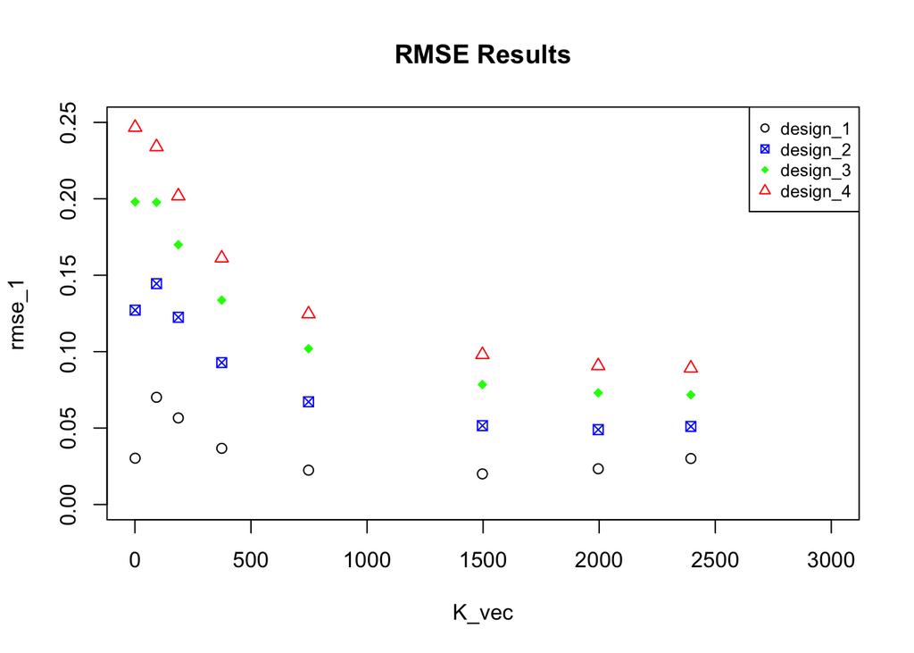

```r
plot(K_vec, rmse_1, col=("black"), main = "RMSE Results", pch = 1, ylim = c(0, 0.25), xlim = c(0, 3000))
points(K_vec,rmse_2, col=("blue"), pch = 7)
points(K_vec,rmse_3, col=("green"), pch = 18)
points(K_vec,rmse_4, col=("red"), pch = 24)
legend("topright", legend=c('design_1','design_2','design_3','design_4'),
       col=c("black", "blue", "green", "red"), pch=c(1,7,18,24), cex=0.8)
```

### Bias

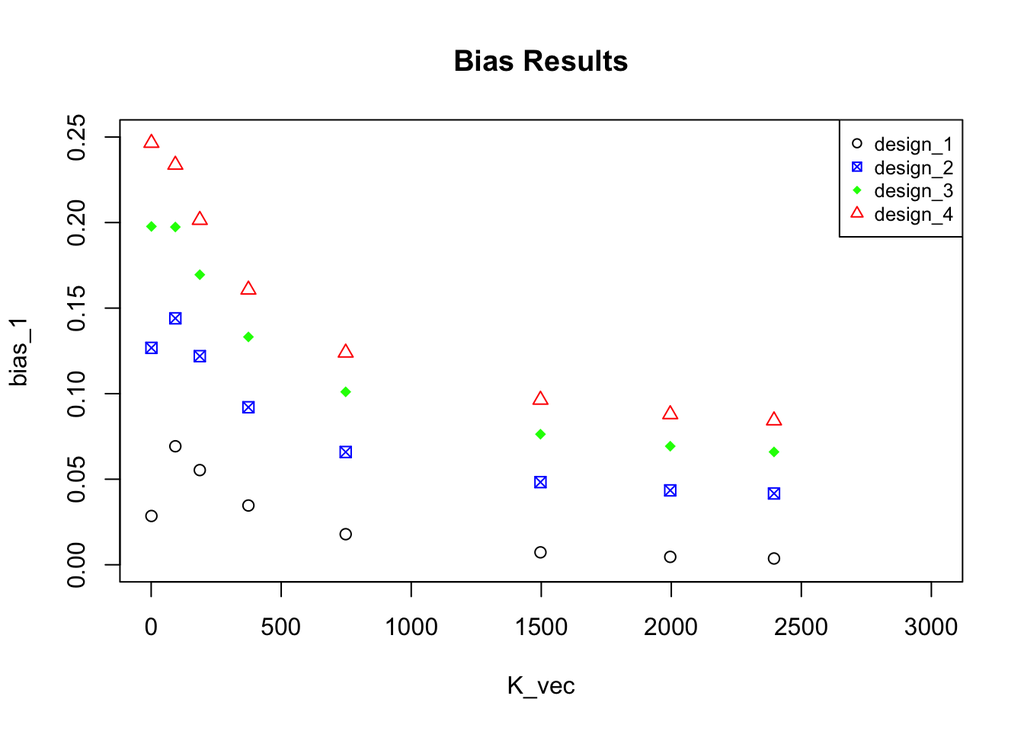

```r
plot(K_vec, bias_1, col=("black"), main = "Bias Results", pch = 1, ylim = c(0, 0.25), xlim = c(0, 3000))
points(K_vec, bias_2, col=("blue"), pch = 7)
points(K_vec, bias_3, col=("green"), pch = 18)
points(K_vec, bias_4, col=("red"), pch = 24)
legend("topright", legend=c('design_1','design_2','design_3','design_4'),
       col=c("black", "blue", "green", "red"), pch=c(1,7,18,24), cex=0.8)
```